# E_Portfolio Summative

Alieu Ceesay

2023-12-07

#### UoB No: “22039518”

# **DIFFERENTIAL EXPRESSION OF GENES IN OSTEOARTHRITIS AND NORMAL SYNOVIAL TISSUE.**

# BACKGROUND.

Osteoarthritis (OA) is a disease that is a burden to global health, affecting 528 million in 2019, which is increasing every year, this number has increased by 113% since 1990, nearly within three decades (World Health Organization: WHO 2023). The prevalence of Osteoarthritis is not very general, it is dependent on a lot of factors like gender, work type, age, and social life. Knee Osteoarthritis contributes to 85% of the other types of Osteoarthritis worldwide (Hunter and Bierma-Zeinstra 2019).

The high-risk population for Osteoarthritis is the elderly, obese, genetic makeup, and people with a high number of knee joint injuries (CDC 2023. In addition for people who are at risk for Knee Osteoarthritis, (Hunter and Bierma-Zeinstra 2019) stated that risk factors such as being female, being obese, and having had previous knee injuries are considered moderate to strong risk factors. People involved in work activities involving heavy lifting and kneeling are also at risk for knee Osteoarthritis (CDC 2023). Some sports activities like football, hockey, wrestling, and heavy lifting put athletes at high risk of knee injuries which are associated with knee Osteoarthritis (Thelin et al. 2005). Osteoarthritis, in general, is not highly induced by our genetic makeup, however, it contributes to 40% to 80% of all Osteoarthritis cases, with Knee Osteoarthritis representing the lowest percentage among the other types of OA (Hunter and B,ierma-Zeinstra 2019).

Although the etiology of the disease is still unknown, it is widely accepted that these degenerative changes arise from an imbalance of synthetic and degradative pathways that control cartilage and synovium extracellular matrix metabolism (Bijlsma et al. 2011). OA affects the entire joint which includes the synovial membrane and it is a heterogeneous disease involving overlapping pathways, depending on the risk factors associated with the OA, however, the outcome of the joint destruction is the same (Hunter and Bierma-Zeinstra 2019). The synovium contributes to the pathogenesis of OA. Some clinical symptoms of OA reflect the synovium inflammation, implicating it as a low-grade contributor to OA (Krasnokutsky et al. 2008). ). The pathogenesis of OA involves mechanical, inflammatory, and metabolic factors, which lead to structural destruction and failure of the synovial fluid (Hunter and Bierma-Zeinstra 2019). Synovitis can occur in the early stages of OA, a study done by (Listrat et al. 1997) shows that 50% of OA patients have localized proliferative and inflammatory changes of the synovium. The main symptom of Knee Osteoarthritis is pain function disability (Bijlsma et al. 2011)

As of 2021, there has been no known curative treatment for OA. Because of the complexity of how OA manifests, many disease-modifying osteoarthritis drugs have been unsuccessful (Kaplon et al. 2021). However, key treatment approaches for OA are education and self-management, exercise, weight loss if obese, and work aid. Pain medications are being used for OA management, to reduce pain, as is the main symptom of OA. Paracetamol and NSAIDs are some of the pain medications used. Furthermore, joint replacement surgery is also a treatment strategy used. For example, NGF (Nerve Growth Factor) has been under development for decades and has shown promising results (Hunter and Bierma-Zeinstra 2019).

Transcriptome is a term for the whole set of RNAs transcribed by the genome from a specific tissue or cell type at a developmental stage and/or under a certain physiological condition (Dong and Chen 2013). In understanding OA, its cause, and a possible cure, transcriptomic has made great progress in the level of gene expression in the blood or a target tissue at the whole transcriptomic level. There are many quantitative transcriptomic methods used in OA study cases using related tissue or blood, all to provide insight into the relative molecular change, differently expressed genes, and protein pathways between a normal sample and a sample with OA (Kaplon et al. 2021). All this information helps us to identify compounds to reverse these changes and processes, looking for a compound that can induce strong opposing genes to reverse the molecular change and processes. For example, a study done by (Steinberg et al. 2021) characterized the molecular difference between low-grade and high-grade cartilage in OA to identify compounds capable of reversing the molecular change and help with a new treatment approach.

In this work, microarray Technology was used, which is a type of transcriptomic analysis that relies on synthetic oligonucleotides spotted on a microchip to assess the expression of genes and allow the identification of differentially expressed genes. The technology can detect species and transcripts-specific gene expression (Kaplon et al. 2021).

# METHOD

This portfolio will discuss the concepts of Osteoarthritis and build an R pipeline to analyze microarray data done and published on GEO (Gene Expression Omnibus) on 1st August 2022. The data was to investigate the expression pattern in non-osteoarthritis (normal) and synovium obtained from OA and rheumatoid arthritis (RA) patients undergoing knee replacement surgery. we will perform differential gene expression analysis to identify genes that show significant differential expression between Osteoarthritis and Normal samples. This data was generated by Attur M and Abramson SB, to understand the disease’s molecular basis better and provide relevant insight into phenotypical alterations and mechanisms involved in OA and rheumatoid arthritis.

Our transcripts are in CEL files, this is a data structure from a GeneChip microarray experiment (Affymetrix). Cel files are a very simple data structure that primarily stores all the probe intensities for a single gene chip (Gautier et al. 2004).

we will use limma package from BioConductor for the Differential expression, BioConductor is an open-source and open-development project to support the analysis of genomic data using R language. It helps in a solid workflow and analysis of biological data, like transcriptomic data (Wilson and Miller 2005).

### PRE-PROCESSING

This step is very vital for the Differential expression analysis. This is where the data is processed before the differential expression.

### DOWNLOADING AND LOADING REQUIRED PACKAGES

```r
#Downloading and Loading Required Packages

#if (!require("BiocManager", quietly = TRUE))
   #install.packages("BiocManager")

#From the Bioconductor
#BiocManager::install("affy")
#BiocManager::install("limma")
#BiocManager::install("hgu133plus2.db")
#BiocManager::install("AnnotationDbi")
##BiocManager::install("clusterProfiler", version = "3.18")
#BiocManager::install("pathview")
#BiocManager::install("enrichplot")

#CRAN packages
#install.packages("ggplot2")
#install.packages("pheatmap")


#Loading the librarys
library(affy)
library(limma)
library(ggplot2)
library(hgu133plus2.db)
library(AnnotationDbi)
library(clusterProfiler)
library(enrichplot)
library(pheatmap)
```

### LOADING TARGETS FILE

Firstly, we load the target files using the readTarget() function from the limma package. The Targets file is in a txt file and describes the design of the experiment.

```r
#loading our target file
targets <- readTargets("/Users/ALIEU CSAY/Desktop/Masters Bioinformatics/Principles of Bioinformatics/E-portfolio/E_portfolio_ass/data .txt")
```

### BACKGROUND CORRECTION AND NORMALISATION.

We use the justRMA () function in affy package for the background correction and normalization of our raw CEL files and save them as an Expressionset (eset). From the microarray experiment, the chip detects some amount of background noise. Therefore, the background correction algorithm of RMA estimates background noise by convoluting signals and noise distribution. Furthermore, the overall distribution of probe intensities differs slightly from chip to chip of the same sample. Therefore, we normalize to detect and correct systematic differences between chips. The function loads the CEL files, background corrections, normalizes intensities or log ratios to be comparable across arrays, and calculates expression (Wilson and Miller 2005). The column names were set to Title, which are short sample names, NS for Healthy samples, and OA for Arthritis with numbers attached.

```r
#Loading the data and Normalisation

eset <- justRMA(filenames = targets$Sample_ID, celfile.path = "/Users/ALIEU CSAY/Desktop/Masters Bioinformatics/Principles of Bioinformatics/E-portfolio/E_portfolio_ass/input/")
#Setting the coloum names to Title

colnames(eset) <- targets$Title
```

### ANNOTATION

The probes_ids alone cannot tell us much therefore we annotate to add useful information to our probes; gene symbols, ENTREID, and Gene name. We use the Affymetrix HG-U133_Plus_2 Array annotation data (chip hgu133plus) to annotate, this was used as the platform for this experiment. We use the AnnotateDbi::seclect function from the AnnotateDbi package to get the information base on our probe list in “Alias”. We store our annotated data in f(Data). To ensure one-to-one mapping of probes and gene symbols, we checked for duplicate probes, which were assigned with two different gene symbols, and removed the duplicates.NAs for probes that were not assigned a symbol from our annotation were removed.

```r
#Annotation

Alias <- rownames(exprs(eset))
fData(eset) <- AnnotationDbi::select(hgu133plus2.db,Alias,c("SYMBOL","ENTREZID","GENENAME"),keytype="PROBEID")
#Identify duplicated probe IDs in the feature data
duplicated_probes <- fData(eset)$PROBEID[duplicated(fData(eset)$PROBEID)]


# filtering out duplicated probes
fData(eset) <- fData(eset)[!duplicated(fData(eset)$PROBEID),]

# Removing NA using symbol
HasSymbol <- !is.na(fData(eset)$SYMBOL)
eset <- eset[HasSymbol, ]
```

## DIFFERENTIAL EXPRESSION

The data is set now for differential expression.

```r
#Differential expression

#Generating a model matrix specifying your design
Group <- factor(targets$Condition, levels = c("Healthy", "Arthritis"))
design <- model.matrix(~0 + Group)
colnames(design) = levels(factor(Group))

#Fit the model to the design
fit <- lmFit(eset, design)

#Making contrast
contrast <- makeContrasts('Arthritis-Healthy', levels = design)

#Empirical Bayes model
fit2 <- contrasts.fit(fit, contrast)
fit2 <- eBayes(fit2)

#Extracting our differential expressed results
Res <- topTable(fit2, number=Inf, adjust.method = 'fdr')

# Summary of our results
Results <- decideTests(fit2)

#creating a new coloum to classify our genes as upregulated or downregulated.

Res$deff.express.gene <- "NO"
# if log2FC > 0 and adj.pvalue < 0.08, set as "UP"
Res$deff.express.gene[Res$logFC > 0 & Res$adj.P.Val < 0.08] <- "UP"
# if log2FC < 0 and adj.pvalue < 0.08, set as "DOWN"
Res$deff.express.gene[Res$logFC < 0 & Res$adj.P.Val < 0.08] <- "DOWN"

Res$delabel <- NA

Res$delabel[Res$deff.express.gene != "NO"] <- Res$SYMBOL [Res$deff.express.gene != "NO"]
```

## GENE ENRICHMENT ANALYSIS

Gene enrichment analysis is to know whether our genes that are differentially expressed have over-represented known biological functions or processes. We use the enrichGO() function from the clusterprofiler package. Gene ontology (GO) consists of three categories: biological processes (BP), molecular mechanisms (MM), and cellular components(CC). In this work, we select “ALL” for the ontology.

```r
#GO Gene Enrichment Analysis for the differential expressed gene

#Define our universe gene symbols (total gene symbols differential expressed)
Universe <- Res$SYMBOL

#Define genes symbols that are upregulated or downregulated
Up_genes <- Res$SYMBOL[Res$deff.express.gene == "UP"]
Down_genes <- Res$SYMBOL[Res$deff.express.gene == "DOWN"]

#Enrichment analysis of upregulated genes

enrich_up <- enrichGO(
  Up_genes,
  hgu133plus2.db,
  keyType = "SYMBOL",
  ont = "ALL",
  pvalueCutoff = 0.05,
  pAdjustMethod = "BH",
  qvalueCutoff = 0.2,
  Universe,
  minGSSize = 10,
  maxGSSize = 1000,
  readable = FALSE,
  pool = FALSE
)

#Enrichment analysis of Downregulated genes
enrich_Down <- enrichGO(
  Down_genes,
  hgu133plus2.db,
  keyType = "SYMBOL",
  ont = "ALL",
  pvalueCutoff = 0.05,
  pAdjustMethod = "BH",
  qvalueCutoff = 0.2,
  Universe,
  minGSSize = 10,
  maxGSSize = 1000,
  readable = FALSE,
  pool = FALSE
)
```

# RESULTS

This results shows the targets file, first six probe ids with their expression values and column names as tittle. The boxplot represents the intensities/expression values after normalization.

```r
#showing our target file
targets
```

```
##                        Sample_ID Title         Source Condition
## 1  GSM6265690_145614hp133a11.cel  NS01 Knee synovium    Healthy
## 2  GSM6265691_145615hp133a11.cel  NS02 Knee synovium    Healthy
## 3  GSM6265692_145616hp133a11.cel  NS03 Knee synovium    Healthy
## 4  GSM6265693_145617hp133a11.cel  NS04 Knee synovium    Healthy
## 5  GSM6265694_145618hp133a11.cel  NS05 Knee synovium    Healthy
## 6  GSM6265695_145621hp133a11.cel  NS08 Knee synovium    Healthy
## 7  GSM6265696_145623hp133a11.cel  NS10 Knee synovium    Healthy
## 8  GSM6265697_140041hp133a11.cel OAS01 Knee synovium  Arthritis
## 9  GSM6265698_140042hp133a11.cel OAS02 Knee synovium  Arthritis
## 10 GSM6265699_140046hp133a11.cel OAS06 Knee synovium  Arthritis
## 11 GSM6265700_140047hp133a11.cel OAS07 Knee synovium  Arthritis
## 12 GSM6265701_140048hp133a11.cel OAS08 Knee synovium  Arthritis
## 13 GSM6265702_140049hp133a11.cel OAS09 Knee synovium  Arthritis
## 14 GSM6265703_140050hp133a11.cel OAS10 Knee synovium  Arthritis
```

```r
#viewing our expression data
head(exprs(eset))
```

```
##               NS01     NS02     NS03     NS04     NS05     NS08     NS10
## 1007_s_at 6.962781 6.873340 7.102745 7.060019 7.363888 6.868549 7.024717
## 1053_at   6.628026 7.092585 6.527346 6.428325 6.688201 6.505364 6.451364
## 117_at    8.260993 8.671966 7.749882 7.947327 8.258344 9.396321 7.919666
## 121_at    7.491127 7.378568 7.344319 7.423109 7.886266 7.344395 7.833762
## 1255_g_at 5.230111 3.513554 4.479955 3.934821 5.915557 4.590823 5.015956
## 1294_at   7.705636 7.103903 7.721499 7.906286 7.870181 7.907196 7.860335
##              OAS01    OAS02    OAS06    OAS07    OAS08    OAS09    OAS10
## 1007_s_at 7.701345 7.301226 8.295281 7.311314 7.786295 7.661025 7.835725
## 1053_at   6.746383 6.437490 6.116910 6.211517 6.026366 6.251672 6.663945
## 117_at    7.899310 7.753855 6.961711 7.907599 6.479558 7.980876 8.098773
## 121_at    8.289703 7.618403 7.893912 7.978369 7.966478 7.704478 7.940361
## 1255_g_at 4.280141 4.202553 4.038745 3.759652 3.714616 6.628488 4.913900
## 1294_at   7.995406 7.858110 7.232572 7.689331 7.907001 8.156444 8.162465
```

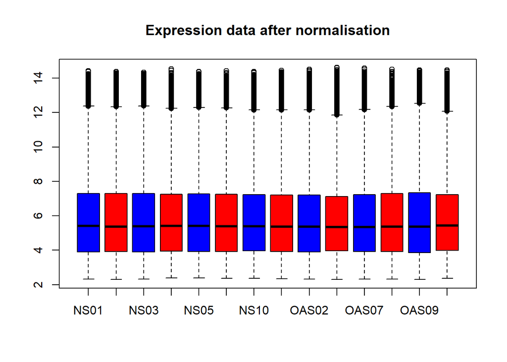

```r
#Boxplot of of our expression data after normalisation
boxplot(exprs(eset), main = "Expression data after normalisation", col = c("blue", "red"))
```

### RESULTS FOR ANNOTATION

This results shows the results if our annotation.

```r
#list our keytypes
keytypes(hgu133plus2.db)
```

```
##  [1] "ACCNUM"       "ALIAS"        "ENSEMBL"      "ENSEMBLPROT"  "ENSEMBLTRANS"
##  [6] "ENTREZID"     "ENZYME"       "EVIDENCE"     "EVIDENCEALL"  "GENENAME"
## [11] "GENETYPE"     "GO"           "GOALL"        "IPI"          "MAP"
## [16] "OMIM"         "ONTOLOGY"     "ONTOLOGYALL"  "PATH"         "PFAM"
## [21] "PMID"         "PROBEID"      "PROSITE"      "REFSEQ"       "SYMBOL"
## [26] "UCSCKG"       "UNIPROT"
```

```r
#viewing our annotated data
head(fData(eset))
```

```
##     PROBEID SYMBOL ENTREZID                                     GENENAME
## 1 1007_s_at   DDR1      780  discoidin domain receptor tyrosine kinase 1
## 2   1053_at   RFC2     5982               replication factor C subunit 2
## 3    117_at  HSPA6     3310 heat shock protein family A (Hsp70) member 6
## 4    121_at   PAX8     7849                                 paired box 8
## 5 1255_g_at GUCA1A     2978               guanylate cyclase activator 1A
## 6   1294_at   UBA7     7318  ubiquitin like modifier activating enzyme 7
```

```r
#viewing our Duplicates probes
head(duplicated_probes)
```

```
## [1] "1552283_s_at" "1552401_a_at" "1552411_at"   "1552412_a_at" "1552449_a_at"
## [6] "1552607_at"
```

```r
#showing summary of our logic report
table(HasSymbol)
```

```
## HasSymbol
## FALSE  TRUE
## 10013 44662
```

```r
#checking the dimension for the eset
dim(eset)
```

```
## Features  Samples
##    44662       14
```

### RESULTS FOR DIFFERENTIAL EXPRESSION

This results shows the first six genes differential expressed with it statistical values, the summary of the results as in number of genes upregulted or dowregulated or non of the two, and finally we plot a volcano plot to represent our overall DEGs results, showing gene symbols for genes with logFC < -1 | logFC > 1.

```r
#Viewing the differential expression results
head(Res)
```

```
##                   PROBEID SYMBOL ENTREZID
## 1555408_at     1555408_at  BAGE2    85319
## 211022_s_at   211022_s_at   ATRX      546
## 1557227_s_at 1557227_s_at    TPR     7175
## 235216_at       235216_at  ESCO1   114799
## 236557_at       236557_at ZBTB38   253461
## 1560017_at     1560017_at  TMTC3   160418
##                                                                      GENENAME
## 1555408_at                                  BAGE family member 2 (pseudogene)
## 211022_s_at                                          ATRX chromatin remodeler
## 1557227_s_at             translocated promoter region, nuclear basket protein
## 235216_at    establishment of sister chromatid cohesion N-acetyltransferase 1
## 236557_at                            zinc finger and BTB domain containing 38
## 1560017_at          transmembrane O-mannosyltransferase targeting cadherins 3
##                   logFC  AveExpr         t      P.Value    adj.P.Val        B
## 1555408_at   -1.9459978 4.880997 -17.81757 2.773563e-11 1.238729e-06 14.66685
## 211022_s_at  -1.6644402 4.530408 -13.70261 1.030825e-09 2.301936e-05 11.95810
## 1557227_s_at -2.4057206 5.781261 -13.05874 1.975562e-09 2.941086e-05 11.43132
## 235216_at    -1.5697476 4.732629 -12.57774 3.270427e-09 3.651595e-05 11.01575
## 236557_at    -0.8667222 6.363256 -12.02618 5.949453e-09 4.584190e-05 10.51448
## 1560017_at   -1.5362290 4.758456 -11.99498 6.158511e-09 4.584190e-05 10.48530
##              deff.express.gene delabel
## 1555408_at                DOWN   BAGE2
## 211022_s_at               DOWN    ATRX
## 1557227_s_at              DOWN     TPR
## 235216_at                 DOWN   ESCO1
## 236557_at                 DOWN  ZBTB38
## 1560017_at                DOWN   TMTC3
```

```r
#showing the summary of the results.
summary(Results)
```

```
##        Arthritis-Healthy
## Down                2456
## NotSig             40799
## Up                  1407
```

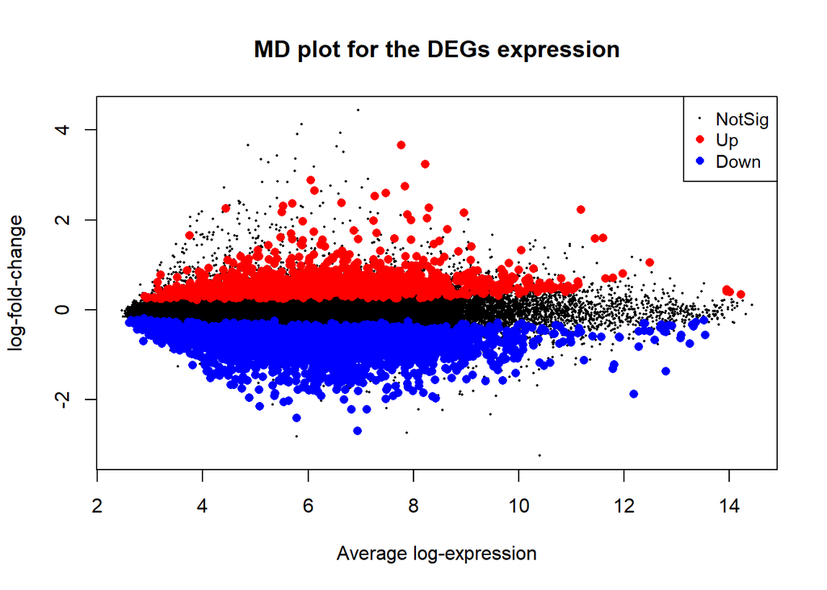

```r
#MD plot for our results, for the distribution of our DEGs
plotMD(fit2, coef="Arthritis-Healthy", status=Results, main = "MD plot for the DEGs expression")
```

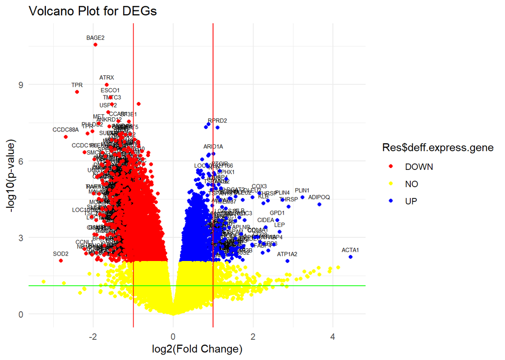

```r
#Volcano plot Differential expressed gene
ggplot(Res, aes(y = -log10(P.Value), x = logFC))+
geom_text(data = subset(Res, logFC < -1 | logFC >  1),aes(label = delabel),nudge_y = 0.3, size = 2) +
geom_point() + labs(y = "-log10(p-value)", x = "log2(Fold Change)") +
ggtitle("Volcano Plot for DEGs") +
geom_point(aes(colour= Res$deff.express.gene)) +
scale_colour_manual(values = c("red","yellow","blue")) +
geom_vline(xintercept = c(-1, 1), colour = "red" ) +
geom_hline(yintercept = -log10(0.08), colour = "green")+
theme_minimal()
```

### RESULTS FOR GENE ENRICHMENT ANALYSIS.

This Results shows us our gene enrichment analysis of the DEGs.

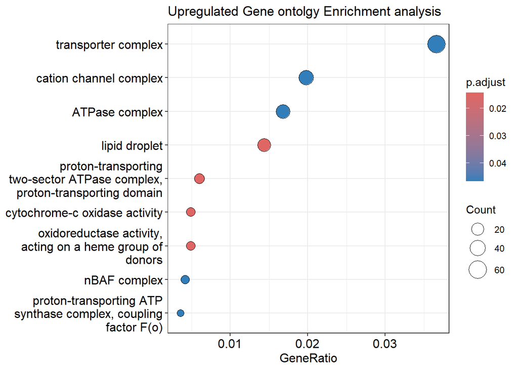

```r
#Enrichment Annalysis

#For upregulated genes
p2 <- dotplot(enrich_up, showCategory=10) + ggtitle("Upregulated Gene ontolgy Enrichment analysis")

p2
```

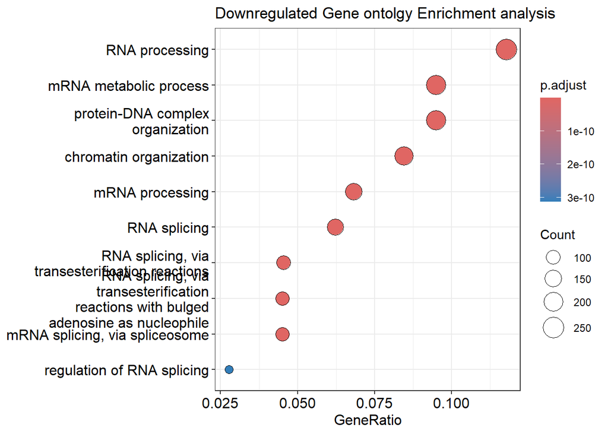

```r
#For downregulated genes
p3 <- dotplot(enrich_Down, showCategory=10) + ggtitle("Downregulated Gene ontolgy Enrichment analysis")
p3
```

# DISCUSSION

In this R pipeline, using bioinformatics analysis, in an attempt to know the molecular changes in OA. The results indicated that thousands of genes in OA synovial tissues have undergone molecular biological changes, with 3863 DEGs determined, including 1407 upregulated and 2456 downregulated genes, compared with normal synovial tissues. The three most strongly significantly upregulated genes and downregulated genes were ACTA1, ADIPOQ, PLINI, and SOD2, CCDC88A, TPR respectively. A study that compares differentially expressed transcripts of osteoarthritis and rheumatoid arthritis has these same top three upregulated genes (Yeremenko et al. 2012).

ACTA1 was the most upregulated gene; it encodes skeletal muscle-actin, which is the predominant actin isoform in the Sarcomeric thin filaments of adult skeletal muscle, essential, along with myosin, for muscle contraction. This gene is largely associated with congenital myopathies; the symptoms of this disease like muscle weakness and imbalance, morbidity challenge, and genetic factors (Laing et al. 2009), might also affect joint tissues or metabolism, potentially influencing the development of OA. ADIPOQ produces adiponectin and causes obesity, which is one of the strongest predictive and prognostic factors for OA (Jiang et al. 2018).

# REFERENCES

1.Kaplon, H., Luo, Y., De Ceuninck, F., Lalande, A., Courtade-Gaiani, S., Laigle, L. and Moingeon, P. (2021) Applications of transcriptomics in support of drug development for osteoarthritis. Osteoarthritis and Cartilage Open 3 (4), 100221.

2. Dong, Z. and Chen, Y. (2013) Transcriptomics: Advances and approaches. Science China Life Sciences 56 (10), 960–967. Wilson, C.L. and Miller, C.J. (2005) Simpleaffy: a BioConductor package for Affymetrix Quality Control and data analysis. Bioinformatics 21 (18), 3683–3685.
3. Gautier, L., Cope, L., Bolstad, B.M. and Irizarry, R.A. (2004) affy—analysis of Affymetrix GeneChip data at the probe level. Bioinformatics 20 (3), 307–315.
4. Thelin, N., Holmberg, S. and Thelin, A. (2005) Knee injuries account for the sports‐related increased risk of knee osteoarthritis. Scandinavian Journal of Medicine & Science in Sports 16 (5), 329–333.
5. CDC (2023) Arthritis Risk Factors. https://www.cdc.gov/arthritis/basics/risk-factors.htm Accessed 4 December 2023. World Health Organization: WHO (2023) Osteoarthritis. World Health Organization: WHO 14 July.
6. Hunter, D.J. and Bierma-Zeinstra, S. (2019) Osteoarthritis. The Lancet 393 (10182), 1745–1759. Bijlsma, J.W., Berenbaum, F. and Lafeber, F.P. (2011) Osteoarthritis: an update with relevance for clinical practice. The Lancet 377 (9783), 2115–2126.
7. Steinberg, J., Southam, L., Roumeliotis, T.I., Clark, M.J., Jayasuriya, R.L., Swift, D., Shah, K.M., Butterfield, N.C., Brooks, R.A., McCaskie, A.W., Bassett, J.H.D., Williams, G.R., Choudhary, J.S., Wilkinson, J.M. and Zeggini, E. (2021) A molecular quantitative trait locus map for osteoarthritis. Nature Communications 12 (1),.
8. Krasnokutsky, S., Attur, M., Palmer, G., Samuels, J. and Abramson, S.B. (2008) Current concepts in the pathogenesis of osteoarthritis. Osteoarthritis and Cartilage 16, S1–S3.
9. Listrat, V., Ayral, X., Patarnello, F., Bonvarlet, J.-P., Simonnet, J., Amor, B. and Dougados, M. (1997) Arthroscopic evaluation of potential structure modifying activity of hyaluronan (Hyalgan®) in osteoarthritis of the knee. Osteoarthritis and Cartilage 5 (3), 153–160.
10. Huang, H., Zheng, J., Shen, N., Wang, G., Zhou, G., Fang, Y., Lin, J. and Zhao, J. (2018) Identification of pathways and genes associated with synovitis in osteoarthritis using bioinformatics analyses. Scientific Reports 8 (1), .
11. Laing, N.G., Dye, D.E., Wallgren-Pettersson, C., Richard, G., Monnier, N., Lillis, S., Winder, T.L., Lochmüller, H., Graziano, C., Mitrani-Rosenbaum, S., Twomey, D., Sparrow, J.C., Beggs, A.H. and Nowak, K.J. (2009b) Mutations and polymorphisms of the skeletal muscle Î±-actin gene (ACTA1). Human Mutation 30 (9), 1267–1277.
12. Scott, J.L., Gabrielides, C., Davidson, R.K., Swingler, T.E., Clark, I.M., Wallis, G.A., Boot-Handford, R.P., Kirkwood, T.B.L., Talyor, R.W. and Young, D.A. (2010) Superoxide dismutase downregulation in osteoarthritis progression and end-stage disease. Annals of the Rheumatic Diseases 69 (8), 1502–1510.
13. Yeremenko, N., Noordenbos, T., Cantaert, T., van Tok, M., van de Sande, M., Cañete, J.D., Tak, P.P. and Baeten, D. (2012) Disease‐specific and inflammation‐independent stromal alterations in spondylarthritis synovitis. Arthritis & Rheumatism 65 (1), 174–185.
14. Jiang, L., Zhu, X., Rong, J., Xing, B., Wang, S., Liu, A., Chu, M. and Huang, G. (2018) Obesity, osteoarthritis and genetic risk. Bone & Joint Research 7 (7), 494–500.